# Diffusion Distance

### [sim] three.13 simulation

$X \sim Multinomial(1/3, 1/3, 1/3)$

$Z \sim \left\{ \begin{array}{cc} Multinorm(\color{red}{0.5}, 0.25, 0.25 ) & X = 1 \\ Multinorm(0.25, \color{red}{0.5}, 0.25 ) & X = 2 \\ Multinorm(0.25, 0.25, \color{red}{0.5} ) & X = 3 \end{array} \right.$

$A \sim Bern \left[ \begin{array}{cc} \color{red}{0.3} & 0.05 & 0.05 \\ 0.05 & \color{red}{0.1} & 0.05 \\ 0.05 & 0.05 & \color{red}{0.2} \end{array} \right]$

#### Power

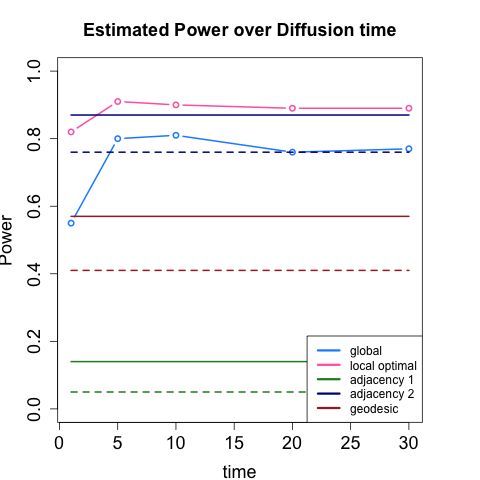

#### Diffusion Process

- t = 1

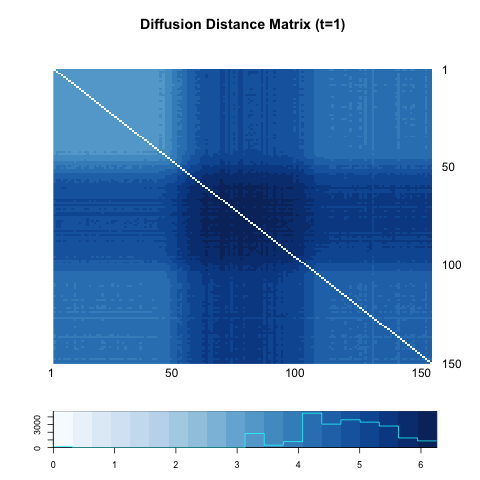

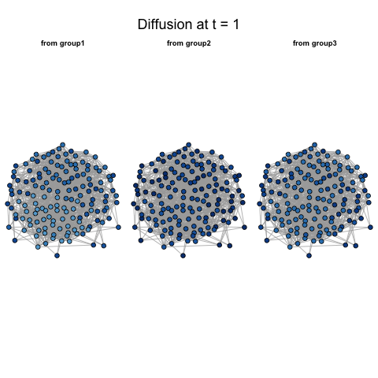

- t = 10

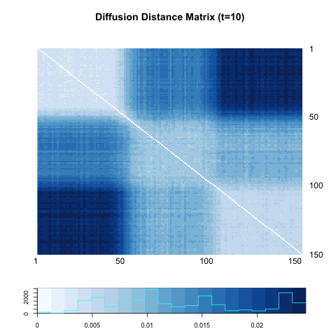

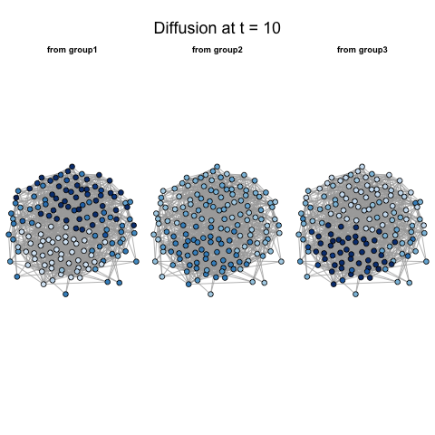

- t = 20

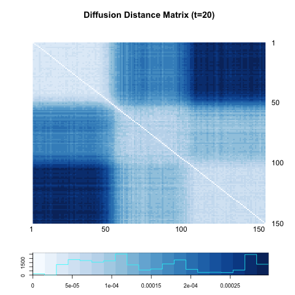

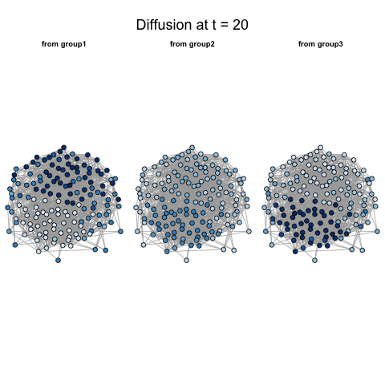

#### Other distance measure

- Non-adjacency (dissimilarity)

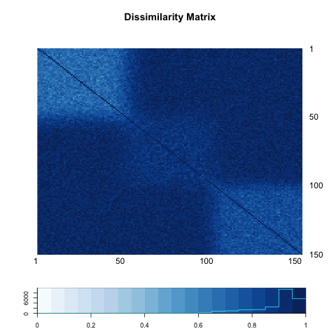

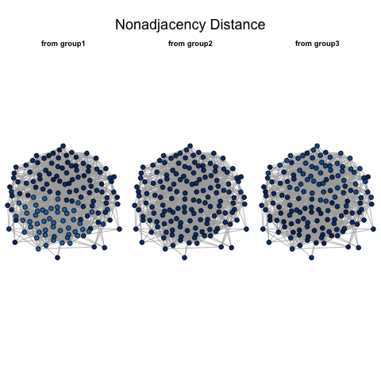

- Euclidean Distance of dissimilarity matrix

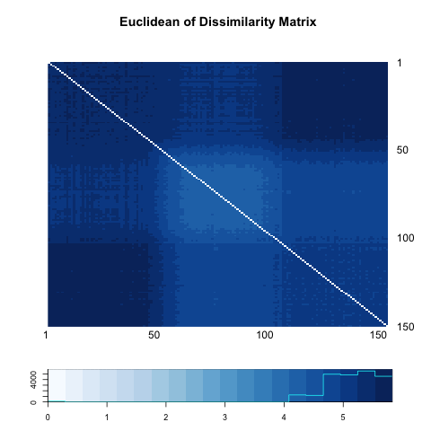

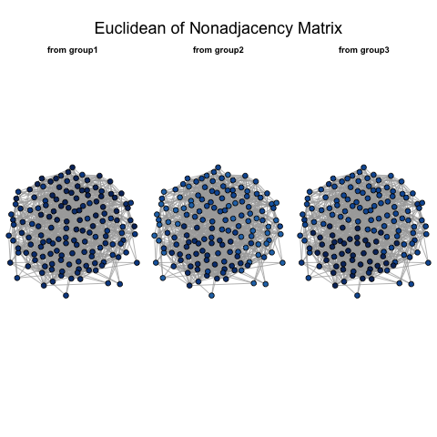

- Geodesic Distance

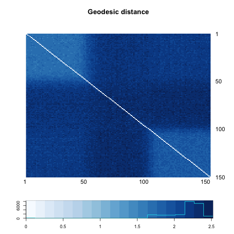

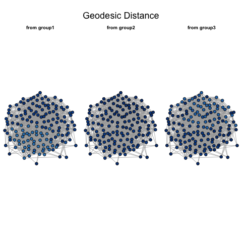

### [sim] three.16 simulation

$X \sim Multinomial(1/3, 1/3, 1/3)$

$Z \sim \left\{ \begin{array}{cc} Multinorm(\color{red}{0.5}, 0.25, 0.25 ) & X = 1 \\ Multinorm(0.25, \color{red}{0.5}, 0.25 ) & X = 2 \\ Multinorm(0.25, 0.25, \color{red}{0.5} ) & X = 3 \end{array} \right.$

$A \sim Bern \left[ \begin{array}{cc} \color{red}{0.2} & 0.1 & 0.1 \\ 0.1 & \color{red}{0.05} & 0.1 \\ 0.1 & 0.1 & \color{red}{0.2} \end{array} \right]$

#### Power

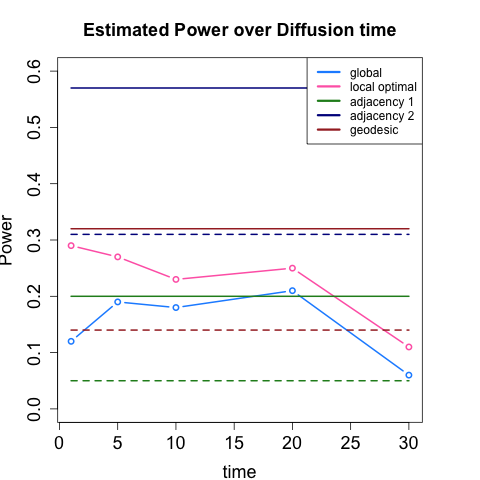

## Appendix

### Proof of triangle inequality

Let $x, y, z \in V(G).$

$\begin{align*} D^{2}_{t}(x,z) & = \sum\limits_{w \in V(G)} \big( P^{t}(x,w) - P^{t}(z,w) \big)^2 \frac{1}{\pi(w)} \\ & = \sum\limits_{w \in V(G)} \big(P^{t}(x, w) - P^{t}(y,w) + P^{t}(y,w) - P^{t}(z,w) \big)^2 \frac{1}{\pi(w)} \\ & = \sum\limits_{w \in V(G)} \big( P^{t}(x,w) - P^{t}(y,w) \big)^2 \frac{1}{\pi(w)} + \sum\limits_{w \in V(G)} \big( P^{t}(y,w) - P^{t}(z,w) \big)^2 \frac{1}{\pi(w)} \\ & + 2 \sum\limits_{w \in V(G)} \big( P^{t}(x,w) - P^{t}(y,w) \big) \big( P^{t}(y,w) - P^{t}(z,w) \big)\frac{1}{\pi(w)} \\ &= D^{2}_{t}(x,y) + D^{2}_{t}(y,z) + 2 \sum\limits_{w \in V(G)} \big( P^{t}(x,w) - P^{t}(y,w) \big) \big( P^{t}(y,w) - P^{t}(z,w) \big)\frac{1}{\pi(w)} \end{align*}.$

Thus it suffices to show that

$\begin{align} \sum\limits_{w \in V(G)} \big( P^{t}(x,w) - P^{t}(y,w) \big) \big( P^{t}(y,w) - P^{t}(z,w) \big)\frac{1}{\pi(w)} \leq D_{t}(x,y) \cdot D_{t}(y,z). \end{align}$

Let $a_{w} = \big(P^{t}(x,w) - P^{t}(y,w) \big) \sqrt{1 / \pi(w)}$ and $b_{w} = \big( P^{t}(y,w) - P^{t}(z,w) \big) \sqrt{1 / \pi(w)}$. Then the above inequality is equivalent to :

$\begin{align} \sum\limits_{w \in V(G)} a_{w} \cdot b_{w} \leq \sqrt{\sum\limits_{w \in V(G)} a^2_{w} \cdot \sum\limits_{w \in V(G)} b^2_{w} } \end{align}$

,which is true by Cauchy-Schwarz inequality.